# TransborderFreight Data Analysis

Ebenezer Omari

This project analyses transportation data from the **Bureau of Transportation Statistics (BTS)** to uncover insights into cross-border freight’s efficiency, safety and environmental impacts across modes such as road, rail, air and water.

## CRISP-DM Framework

The analysis followed the CRISP-DM methodology, which includes the following stages:

## 1. Business Understanding

The objectives were defined below, followed by the formulation of analytic questions to guide the analysis process.

### Objectives

- **Freight Patterns**: Identify trends in freight volume, routing and modes of transport.
- **Operational Efficiency**: Detect inefficiencies and propose resource optimization strategies.
- **Environmental Impact**: Assess emissions and fuel usage, recommending sustainability improvements.
- **Safety Analysis**: Evaluate incidents and suggest safety protocol enhancements.
- **Economic Effects**: Analyze the impact of trade patterns, policies and global disruptions.
- **Data-Driven Solutions**: Provide actionable recommendations for improving freight systems.

### Analytic Questions:

1. What are the top modes of transportation by freight value?
2. What are the top modes of transportation by freight value in the US states?
3. Which US state contributes the most to freight weight?
4. What is the correlation between Freight Value, Shipment Weight and Freight Charges for each year from 2020 to 2024?
5. How has the total freight value changed over the years from 2020 to 2024?
6. How do import and export values compare across different states in the US?
7. What is the variability in shipment weights for exports versus imports?
   - Do exports or imports show more consistency or is one category more prone to outliers?

## 2. Data Understanding

The data set consisted of 6,517,225 records and 15 variables. Key variables included:

a. TRDTYPE: Transaction type.

b. USASTATE, MEXSTATE, CANPROV: Regions involved in freight movement.

c. VALUE: Value of goods in USD.

d. SHIPWT: Shipment weight.

e. FREIGHT_CHARGES: Associated transportation costs.

f. MONTH

g. YEAR

## 3. Data Preparation

```r
# Fill the NA's in the DEPE column
# Define a function to calculate the mode (most frequent value)
getmode <- function(v) {
  uniq_v_depe <- unique(na.omit(v))
  uniq_v_depe[which.max(tabulate(match(v, uniq_v_depe)))]
}

# Calculate the most frequent DEPE for each USASTATE
mode_depe_by_state <- data %>%
  group_by(USASTATE) %>%
  summarise(mode_DEPE = getmode(DEPE), .groups = "drop")

# Fill in missing DEPE values based on the mode for the respective USASTATE
data <- data %>%
  left_join(mode_depe_by_state, by = "USASTATE") %>%
  mutate(DEPE = if_else(is.na(DEPE), mode_DEPE, DEPE)) %>%
  select(-mode_DEPE)
```

```r
# Condition Mismatch:
# The code only fills missing values for rows that meet the specific conditions: For MEXSTATE, it fills NA's only when both MEXSTATE and CANPROV are missing and COUNTRY equals 2010. For CANPROV, it fills NA's only when both are missing and COUNTRY equals 1220. Check whether the remaining NA's have different COUNTRY values or if only one of the two columns is missing. If so, they won’t be matched by your masks.

# Define a function to calculate the mode (most frequent value)
getmode <- function(v) {
  uniqv <- unique(na.omit(v))
  uniqv[which.max(tabulate(match(v, uniqv)))]
}

# Create a mask for rows where MEXSTATE and CANPROV are NA and COUNTRY equals 2010
mex_mask <- is.na(data$MEXSTATE) & is.na(data$CANPROV) & (data$COUNTRY == 2010)

# Fill missing MEXSTATE values (for those rows) with the mode of the MEXSTATE column
data$MEXSTATE[mex_mask] <- getmode(data$MEXSTATE)

# Create a mask for rows where MEXSTATE and CANPROV are NA and COUNTRY equals 1220
can_mask <- is.na(data$MEXSTATE) & is.na(data$CANPROV) & (data$COUNTRY == 1220)

# Fill missing CANPROV values (for those rows) with the mode of the CANPROV column
data$CANPROV[can_mask] <- getmode(data$CANPROV)
```

```r
# Since they are still missing NA's  this code uses column-specific conditions or individual imputation conditions. This means that each column is evaluated independently for missing values, rather than requiring a combined condition (i.e. both columns missing) for imputation.

# Define a function to calculate the mode (most frequent value)
getmode <- function(v) {
  uniq_v <- unique(na.omit(v))
  uniq_v[which.max(tabulate(match(v, uniq_v)))]
}

# For MEXSTATE: Fill all NA values
mex_mask <- is.na(data$MEXSTATE)
data$MEXSTATE[mex_mask] <- getmode(data$MEXSTATE)

# For CANPROV: Fill all NA values
can_mask <- is.na(data$CANPROV)
data$CANPROV[can_mask] <- getmode(data$CANPROV)
```

## 4. Analysis and Visualization

| Total_Value | Total_ShipWt | Total_Freight_Charges | Avg_Value | Avg_ShipWt | Avg_Freight_Charges |
| --- | --- | --- | --- | --- | --- |
| 1.919841e+13 | 7.823297e+12 | 251016362398 | 2945795 | 1200403 | 38515.83 |

|  | Total_Value | Total_ShipWt | Total_Freight_Charges | Avg_Value | Avg_ShipWt | Avg_Freight_Charges |
| --- | --- | --- | --- | --- | --- | --- |
| 1 | 19,198,406,820,228 | 7,823,297,450,099 | 251,016,362,398 | 2,945,795 | 1,200,403 | 38,515.83 |

| Total_Value | Total_ShipWt | Total_Freight_Charges | Avg_Value | Avg_ShipWt | Avg_Freight_Charges |
| --- | --- | --- | --- | --- | --- |
| 1.919841e+13 | 7.823297e+12 | 251016362398 | 2945795 | 1200403 | 38515.83 |

The data set covered multiple years and regions, with data on road, rail, air sand water transport modes. Summary statistics across the data set (2020 – 2024) revealed:

Total Value: The cumulative value of all freight transactions across the data set is 19.20 trillion USD. This metric highlights the enormous scale of trans-border freight in terms of monetary value.

Total Shipment Weight: The total shipping weight of goods transported is 7.82 trillion kg. This gave an idea of the physical scale of goods being moved.

Total Freight Charges: The total freight charges across all transactions amount to 251.02 billion USD, showing the financial cost of transportation.

The data set covered multiple years and regions, with data on road, rail, air sand water transport modes.

Key Findings from the analytic questions:

**What are the top modes of transportation by freight volume and value?**

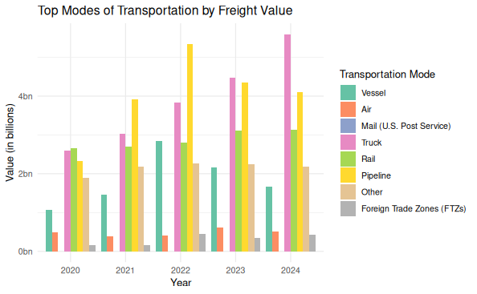

Key Observations:

Trucks and pipeline dominates the freight value across most years, indicating their importance in domestic and regional transportation.

Air transportation, while less significant in terms of value, consistently contributes a notable portion of the freight value, highlighting its role in high-value shipments.

Pipelines and vessels also contribute significantly, particularly for specific years where bulk commodities like oil or goods with high shipping requirements were involved.

**What are the top modes of transportation by freight value in the US states?**

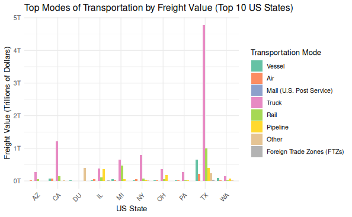

Analysis:

Notably, truck transportation overwhelmingly dominates the freight value. Texas is particularly prominent, with truck freight value exceeding 4.5 trillion USD, far surpassing the contributions of other states. California also shows significant activity, recording over 1 trillion USD in truck freight value. In contrast, other modes such as rail, air and pipeline consistently contribute less, with freight values remaining below 1 trillion USD across these states.

These observations indicate that truck transport is the critical driver of freight value in the US, especially in key states like Texas and California, while the contribution of other modes is relatively modest.

This dominance suggests that the environmental impact of freight transportation is largely driven by truck-related emissions and fuel usage. Trucks generally have higher greenhouse gas emissions and lower fuel efficiency compared to modes such as rail or pipeline.

**Environmental Impact Assessment:**

- **Emissions & Fuel Usage:**  
  Trucking typically relies on diesel, which emits significant levels of CO₂, NOₓ, and particulate matter. Given that truck freight value far exceeds that of other modes (with Texas exceeding 4.5 trillion USD and California over 1 trillion USD), it implies high fuel consumption and, consequently, a larger carbon footprint.
- **Sustainability Considerations:**  
  Other modes, such as rail, air and pipeline, contribute much less to freight value (often below 1 trillion USD), and these modes generally offer more efficient, lower-emission alternatives for bulk commodities. The heavy reliance on truck transport therefore suggests that there is considerable scope for sustainability improvements.

**Which US state contributes the most to ship weight**

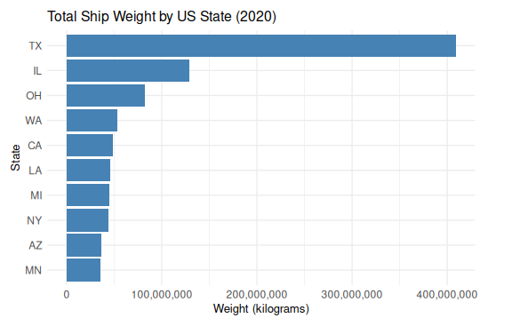

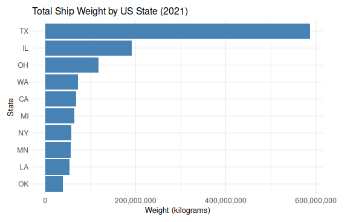

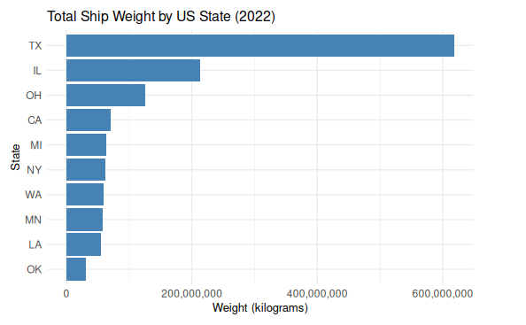

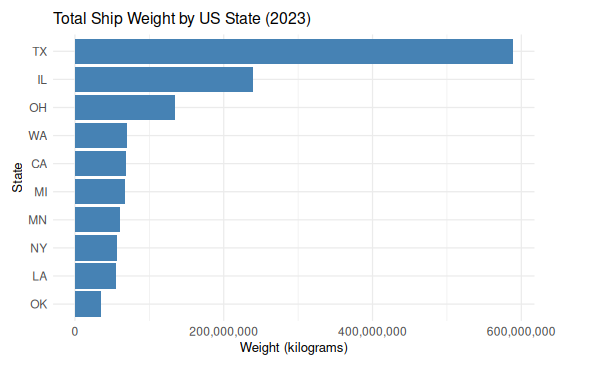

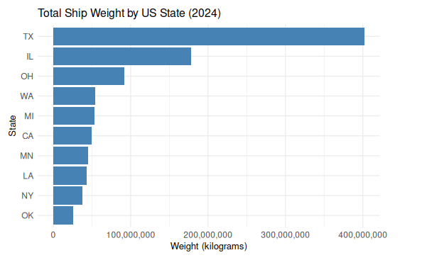

Analysis:

The states with the highest freight weight include Texas followed by Illinois and Ohio. Texas led by a significant margin throughout the years from 2020 to 2024, reflecting its central role, in freight logistics, possibly due to its major ports and highways.

**What is the correlation between Freight Value, Shipment Weight and Freight Charges for each year from 2020 to 2024?**

```
[1] "Correlation Matrix for Year: 2020"
                    VALUE    SHIPWT FREIGHT_CHARGES
VALUE           1.0000000 0.3974324       0.4484026
SHIPWT          0.3974324 1.0000000       0.8613307
FREIGHT_CHARGES 0.4484026 0.8613307       1.0000000
[1] "Correlation Matrix for Year: 2021"
                    VALUE    SHIPWT FREIGHT_CHARGES
VALUE           1.0000000 0.5379743       0.5726583
SHIPWT          0.5379743 1.0000000       0.8700373
FREIGHT_CHARGES 0.5726583 0.8700373       1.0000000
[1] "Correlation Matrix for Year: 2022"
                    VALUE    SHIPWT FREIGHT_CHARGES
VALUE           1.0000000 0.6441426       0.6369829
SHIPWT          0.6441426 1.0000000       0.8517605
FREIGHT_CHARGES 0.6369829 0.8517605       1.0000000
[1] "Correlation Matrix for Year: 2023"
                    VALUE    SHIPWT FREIGHT_CHARGES
VALUE           1.0000000 0.5635678       0.5892625
SHIPWT          0.5635678 1.0000000       0.8874414
FREIGHT_CHARGES 0.5892625 0.8874414       1.0000000
[1] "Correlation Matrix for Year: 2024"
                    VALUE    SHIPWT FREIGHT_CHARGES
VALUE           1.0000000 0.5298914       0.5688139
SHIPWT          0.5298914 1.0000000       0.9131951
FREIGHT_CHARGES 0.5688139 0.9131951       1.0000000
```

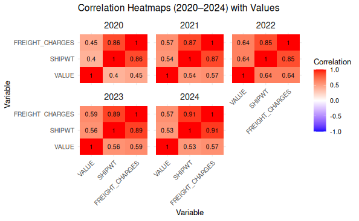

Analysis from 2020:

- Freight Value vs. Shipment Weight (0.40): A moderate positive correlation indicates that higher shipment weight is associated with an increase in freight value, though the relationship is not strong.
- Freight Value vs. Freight Charges (0.45): A moderate positive correlation suggests that higher freight value tend to be associated with higher freight charges.
- Shipment Weight vs. Freight Charges (0.86): A strong positive correlation implies that heavier shipments tend to incur higher freight charges.

Analysis from 2021:

- Freight Value vs. Shipment Weight (0.54): A moderate positive correlation, slightly stronger than in 2020, shows an increasing association between shipment weight and freight value.
- Freight Value vs. Freight Charges (0.57): A moderate positive correlation, also stronger than in 2020, highlights a growing relationship between freight value and freight charges.
- Shipment Weight vs. Freight Charges (0.87): The strong positive correlation remains consistent, indicating a continued link between shipment weight and charges.

Analysis for 2023:

- Freight Value vs. Shipment Weight (0.56): A moderate positive correlation, lower than 2022, indicates the relationship between value and shipment weight weakened slightly.
- Freight Value vs. Freight Charges (0.59): A consistent moderate positive correlation reflects a stable association between freight value and charges.
- Shipment Weight vs. Freight Charges (0.89): The strong positive correlation indicates the relationship remains solid between shipment weight and charges

Analysis for 2024:

- Freight Value vs. Shipment Weight (0.53): A moderate positive correlation, slightly lower than in 2023, suggests a declining association.
- Freight Value vs. Freight Charges (0.57): The consistent correlation indicates that freight value and charges remain moderately linked.
- Shipment Weight vs. Freight Charges (0.91): A very strong positive correlation indicates an almost linear relationship, suggesting that heavier shipments are nearly directly proportional to higher freight charges.

**How has the total freight value changed over the years from 2020 to 2024?**

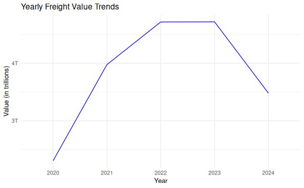

Analysis of Freight Value Trends (2020-2024):

From the data:

Insights:

Increased global trade and an expansion in freight services, especially after 2020 (potentially post-pandemic recovery)

The decline in 2024 is noteworthy and may warrant further investigation to understand the underlying reasons such as economic shifts, changes in trade policy or other market dynamics.

**How do import and export values compare across different states in the US?**

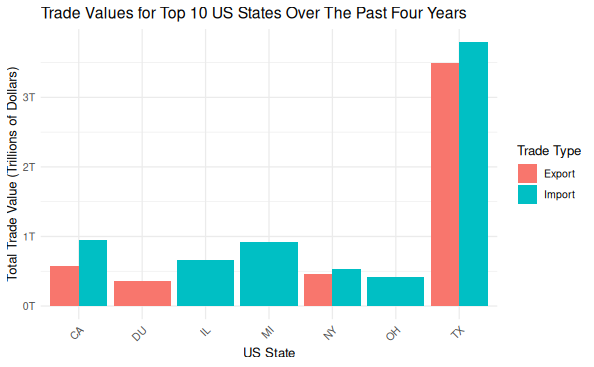

### **Trade Value Analysis**

In particular, Texas stands out with a high import value while also leading in exports, positioning it as a major hub for both inbound and outbound goods. In contrast, California’s trade profile is characterized by a substantial import value that far exceeds its export figures.

**What is the variability in shipment weights for exports versus imports?**

Do exports or imports show more consistency, or is one category more prone to outliers?

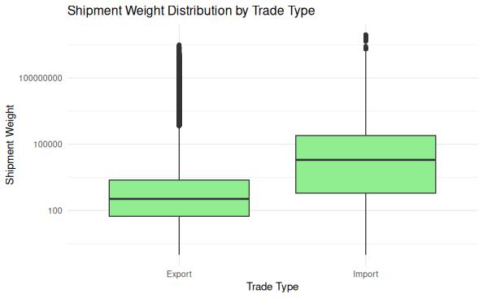

The box plot comparing shipment weight for exports and imports reveals several key insights. First, the median shipment weight for imports is higher than that for exports, indicating that, on average, import shipments tend to be heavier. The export distribution, shown by a smaller box, suggests less variability and more consistency in shipment weight, whereas the import distribution is more spread out, pointing to greater variability among import shipments.

## **Confirmatory Data Analysis**

H₀ (null): Freight Value has no effect on trade type

H₁ (alternative): Freight Value affects Trade Type

Dependent variable (y): Trade type

Independent variable (x): Freight value

Significant level (a): 5% or 0.05

```
Call:
glm(formula = TRDTYPE ~ VALUE, family = binomial, data = data)

Coefficients:
                     Estimate        Std. Error z value            Pr(>|z|)
(Intercept) -0.69605744214916  0.00083810262693 -830.52 <0.0000000000000002 ***
VALUE        0.00000000414899  0.00000000004588   90.43 <0.0000000000000002 ***
---
Signif. codes:  0 ‘***’ 0.001 ‘**’ 0.01 ‘*’ 0.05 ‘.’ 0.1 ‘ ’ 1

(Dispersion parameter for binomial family taken to be 1)

    Null deviance: 8313367  on 6517224  degrees of freedom
Residual deviance: 8300197  on 6517223  degrees of freedom
AIC: 8300201

Number of Fisher Scoring iterations: 5
```

**Analysis:**

**Coefficients**

VALUE:

- Estimate: 0.00000000414899 (4.15e-09)

**Statistical significance:**

**Interpretation:**

Significance of VALUE: The freight value is a statistically significant predictor of trade type. Despite the very small coefficient (due to the scale of VALUE), the extremely low p-value indicates that the relationship is highly unlikely to be due to random chance.

Effect Size: Because VALUE is measured in dollars, its coefficient (approximately 4.15e-09 per dollar) might seem negligible at first glance. However, if changes are considered on a larger scale (e.g., per million dollars), the effect becomes more interpretable. For example, a one million dollar increase in freight value would increase the log-odds of the trade type by about 0.00415.

**Conclusion:**

- Null Hypothesis (H₀): Freight value has no effect on trade type.
- Alternative Hypothesis (H₁): Freight value affects trade type.

Since the coefficient of the VALUE is highly statistically significant, p value < a, the null hypothesis is rejected, which concludes that Freight value affects trade type.

## 5. Insights and Conclusions:

The analysis of the transborder freight data from 2020 to 2024 reveals several important trends and insights. Freight value increased steadily from 2020 to 2023, with particularly significant jumps in 2021 and 2022, suggesting a robust post-pandemic recovery and growth in freight activities. However, 2024 witnessed a decline, indicating a possible market correction or changing trade dynamics.

In terms of transportation modes, truck transport emerged as the dominant contributor to freight value, especially in key states such as Texas and California. Other modes such as rail, air and pipeline contributed significantly less, which underscores the reliance on road transport in the current freight ecosystem.

Furthermore, the correlation analysis demonstrated a strong, consistent relationship between shipment weight and freight charges, reinforcing that heavier shipments incur higher costs.

## Recommendations :

Based on these findings, the following recommendations are proposed:

- Given the dominance of truck transport in freight value, it is advisable to enhance and modernise the trucking infrastructure, particularly in states with high freight activity such as Texas and California. Invest in cleaner technologies for truck fleets, including electric, hybrid, or alternative-fuel vehicles, to reduce per-vehicle emissions.
- Recommendations for reducing carbon foot printing includes: Encourage a shift from truck to more sustainable modes such as rail and pipeline, especially for long-haul and bulk commodity shipments. Introduce incentives, such as tax credits or subsidies, for companies that adopt low-carbon technologies and practices in freight transport. Collect and analyse detailed data on emissions, fuel usage, and other sustainability metrics to monitor progress and identify further opportunities for improvement.
- The marked growth in freight value from 2020 to 2023 followed by a decline in 2024 suggests that continuous monitoring is essential. Stakeholders should implement regular reviews of freight performance metrics to anticipate market shifts and respond promptly.
- With a strong correlation between shipment weight and freight charges, there is scope to improve operational efficiency. Strategies to optimise shipment consolidation and routing may help reduce costs.
- The experience with missing values underscores the importance of understanding the context and source of incomplete data. Future data collection processes should aim to minimise missing entries, while ongoing data analysis should continue to use informed, context-specific imputation methods to reduce bias.

## 6. Deployment

Insights and visualizations were shared via:

- GitHub Repository: Includes documentation, R script and data files.